# Practical Machine Learning Project - Weight Lifting Activity Recogition

Ankit Gupta

Monday, June 15, 2015

## Executive Summary

Using machine learning algorithm, the project aims to predict the manner in which users performed the exercises using “classe” variable in the training data set. The model to categorise the activity will be built using Random Forest algorithm, leveraging the following benefits -

- Accuracy
- Runs efficiently on large data bases
- Handles thousands of input variables without variable deletion
- Gives estimates of what variables are important in the classification
- Generates an internal unbiased estimate of the generalization error as the forest building progresses
- Provides effective methods for estimating missing data
- Maintains accuracy when a large proportion of the data are missing
- Provides methods for balancing error in class population unbalanced data sets
- Generated forests can be saved for future use on other data
- Offers an experimental method for detecting variable interactions (Source: Data Science Central Blog)

## Initialising Environment

```r
#Set the working directory
setwd("C:/Coursera/Data Science/Practical Machine Learning/assignment/")

#Import the required libraries
library(caret)
library(randomForest)
```

## Data Processing

The model building will start by creating training and test datasets from the available CSV files.

```r
train <- read.csv("pml-training.csv", header = T)
test <- read.csv("pml-testing.csv", header = T)
str(train)
```

```
## 'data.frame':    19622 obs. of  160 variables:
##  $ X                       : int  1 2 3 4 5 6 7 8 9 10 ...
##  $ user_name               : Factor w/ 6 levels "adelmo","carlitos",..: 2 2 2 2 2 2 2 2 2 2 ...
##  $ raw_timestamp_part_1    : int  1323084231 1323084231 1323084231 1323084232 1323084232 1323084232 1323084232 1323084232 1323084232 1323084232 ...
##  $ raw_timestamp_part_2    : int  788290 808298 820366 120339 196328 304277 368296 440390 484323 484434 ...
##  $ cvtd_timestamp          : Factor w/ 20 levels "02/12/2011 13:32",..: 9 9 9 9 9 9 9 9 9 9 ...
##  $ new_window              : Factor w/ 2 levels "no","yes": 1 1 1 1 1 1 1 1 1 1 ...
##  $ num_window              : int  11 11 11 12 12 12 12 12 12 12 ...
##  $ roll_belt               : num  1.41 1.41 1.42 1.48 1.48 1.45 1.42 1.42 1.43 1.45 ...
##  $ pitch_belt              : num  8.07 8.07 8.07 8.05 8.07 8.06 8.09 8.13 8.16 8.17 ...
##  $ yaw_belt                : num  -94.4 -94.4 -94.4 -94.4 -94.4 -94.4 -94.4 -94.4 -94.4 -94.4 ...
##  $ total_accel_belt        : int  3 3 3 3 3 3 3 3 3 3 ...
##  $ kurtosis_roll_belt      : Factor w/ 397 levels "","-0.016850",..: 1 1 1 1 1 1 1 1 1 1 ...
##  $ kurtosis_picth_belt     : Factor w/ 317 levels "","-0.021887",..: 1 1 1 1 1 1 1 1 1 1 ...
##  $ kurtosis_yaw_belt       : Factor w/ 2 levels "","#DIV/0!": 1 1 1 1 1 1 1 1 1 1 ...
```

[output cut: 86 more lines]

```r
str(test)
```

```
## 'data.frame':    20 obs. of  160 variables:
##  $ X                       : int  1 2 3 4 5 6 7 8 9 10 ...
##  $ user_name               : Factor w/ 6 levels "adelmo","carlitos",..: 6 5 5 1 4 5 5 5 2 3 ...
##  $ raw_timestamp_part_1    : int  1323095002 1322673067 1322673075 1322832789 1322489635 1322673149 1322673128 1322673076 1323084240 1322837822 ...
##  $ raw_timestamp_part_2    : int  868349 778725 342967 560311 814776 510661 766645 54671 916313 384285 ...
##  $ cvtd_timestamp          : Factor w/ 11 levels "02/12/2011 13:33",..: 5 10 10 1 6 11 11 10 3 2 ...
##  $ new_window              : Factor w/ 1 level "no": 1 1 1 1 1 1 1 1 1 1 ...
##  $ num_window              : int  74 431 439 194 235 504 485 440 323 664 ...
##  $ roll_belt               : num  123 1.02 0.87 125 1.35 -5.92 1.2 0.43 0.93 114 ...
##  $ pitch_belt              : num  27 4.87 1.82 -41.6 3.33 1.59 4.44 4.15 6.72 22.4 ...
##  $ yaw_belt                : num  -4.75 -88.9 -88.5 162 -88.6 -87.7 -87.3 -88.5 -93.7 -13.1 ...
##  $ total_accel_belt        : int  20 4 5 17 3 4 4 4 4 18 ...
##  $ kurtosis_roll_belt      : logi  NA NA NA NA NA NA ...
##  $ kurtosis_picth_belt     : logi  NA NA NA NA NA NA ...
##  $ kurtosis_yaw_belt       : logi  NA NA NA NA NA NA ...
```

[output cut: 86 more lines]

### Handling Missing Data Columns

The first step after creating train dataset is to handle missing values and NA’s in the training and test datasets. Initial investigation shows presence of missing values and NA’s in various columns of train dataset. Let’s create a logical vector “miss” to capture if a particular column in test data set contains missing of NA value. It is important to note here that data cleansing is being done by identifying columns in “test” dataset since the prediction model will be applied and tested on the test dataset. The problematic columns identified in test data set will also be matched in train dataset to reduce the number of predictors, thereby yielding in better accuracy. Also since the problem statement is concerned with activities pertaining to “belt”, “arm”, “forearm”, “dumbbell”, only the columns with names containing these keywords will be considered as predictors.

```r
#Create a logical vector to identify missing and NA values in test dataset.
miss <- sapply(test, function(x) any(is.na(x) | x == ""))
#Consider column names with "belt", "arm", "dumbbell" keywords
isVar <- !miss & grepl("belt|arm|dumbbell", names(miss))
predictors <- names(miss)[isVar]
```

### Subset training Dataset

With the help of predictors vector, a subset of training dataset is created. As evident, the number of predictors has been reduced from substantially from 160 to 53 including “classe” variable which is to be predicted.

```r
train <- train[, c("classe", predictors)]
str(train)
```

```
## 'data.frame':    19622 obs. of  53 variables:
##  $ classe              : Factor w/ 5 levels "A","B","C","D",..: 1 1 1 1 1 1 1 1 1 1 ...
##  $ roll_belt           : num  1.41 1.41 1.42 1.48 1.48 1.45 1.42 1.42 1.43 1.45 ...
##  $ pitch_belt          : num  8.07 8.07 8.07 8.05 8.07 8.06 8.09 8.13 8.16 8.17 ...
##  $ yaw_belt            : num  -94.4 -94.4 -94.4 -94.4 -94.4 -94.4 -94.4 -94.4 -94.4 -94.4 ...
##  $ total_accel_belt    : int  3 3 3 3 3 3 3 3 3 3 ...
##  $ gyros_belt_x        : num  0 0.02 0 0.02 0.02 0.02 0.02 0.02 0.02 0.03 ...
##  $ gyros_belt_y        : num  0 0 0 0 0.02 0 0 0 0 0 ...
##  $ gyros_belt_z        : num  -0.02 -0.02 -0.02 -0.03 -0.02 -0.02 -0.02 -0.02 -0.02 0 ...
##  $ accel_belt_x        : int  -21 -22 -20 -22 -21 -21 -22 -22 -20 -21 ...
##  $ accel_belt_y        : int  4 4 5 3 2 4 3 4 2 4 ...
##  $ accel_belt_z        : int  22 22 23 21 24 21 21 21 24 22 ...
##  $ magnet_belt_x       : int  -3 -7 -2 -6 -6 0 -4 -2 1 -3 ...
##  $ magnet_belt_y       : int  599 608 600 604 600 603 599 603 602 609 ...
##  $ magnet_belt_z       : int  -313 -311 -305 -310 -302 -312 -311 -313 -312 -308 ...
```

[output cut: 39 more lines]

### Data Split for Cross Validation

Before applying the model on test dataset, the effect of model will be measure and verfied by splitting training dataset in two parts “sub.train” and “cross.val” data frame. sub.train will be used to build the model and cross.val will be used to measure the accruracy and error rate of the model.

```r
inTrain <- createDataPartition(train$classe, p = .6, list = F)

sub.train <- train[inTrain,]
cross.val <- train[-inTrain, ]

preProc <- preProcess(sub.train[, -1])
preProc
```

```
##
## Call:
## preProcess.default(x = sub.train[, -1])
##
## Created from 11776 samples and 52 variables
## Pre-processing: centered, scaled
```

```r
nzv <- nearZeroVar(sub.train, saveMetrics = T)
nzv
```

```
##                      freqRatio percentUnique zeroVar   nzv
## classe                1.469065    0.04245924   FALSE FALSE
## roll_belt             1.149225    8.81453804   FALSE FALSE
## pitch_belt            1.140187   13.84171196   FALSE FALSE
## yaw_belt              1.038710   14.27479620   FALSE FALSE
## total_accel_belt      1.082882    0.23777174   FALSE FALSE
## gyros_belt_x          1.071776    1.04449728   FALSE FALSE
## gyros_belt_y          1.158388    0.54347826   FALSE FALSE
## gyros_belt_z          1.069392    1.37567935   FALSE FALSE
## accel_belt_x          1.026860    1.34171196   FALSE FALSE
## accel_belt_y          1.069620    1.13790761   FALSE FALSE
## accel_belt_z          1.016917    2.40319293   FALSE FALSE
## magnet_belt_x         1.191176    2.45414402   FALSE FALSE
## magnet_belt_y         1.027919    2.46263587   FALSE FALSE
## magnet_belt_z         1.054745    3.55808424   FALSE FALSE
## roll_arm             50.000000   19.41236413   FALSE FALSE
## pitch_arm            84.000000   22.38451087   FALSE FALSE
## yaw_arm              32.812500   21.17866848   FALSE FALSE
## total_accel_arm       1.005587    0.55197011   FALSE FALSE
## gyros_arm_x           1.003165    5.26494565   FALSE FALSE
## gyros_arm_y           1.366154    3.09103261   FALSE FALSE
## gyros_arm_z           1.123810    1.99558424   FALSE FALSE
## accel_arm_x           1.008929    6.43682065   FALSE FALSE
## accel_arm_y           1.075758    4.39877717   FALSE FALSE
## accel_arm_z           1.000000    6.46229620   FALSE FALSE
## magnet_arm_x          1.054545   11.06487772   FALSE FALSE
## magnet_arm_y          1.019608    7.19259511   FALSE FALSE
## magnet_arm_z          1.061538   10.52139946   FALSE FALSE
## roll_dumbbell         1.012821   87.74626359   FALSE FALSE
## pitch_dumbbell        2.253165   85.57235054   FALSE FALSE
## yaw_dumbbell          1.025974   87.13485054   FALSE FALSE
## total_accel_dumbbell  1.111253    0.35665761   FALSE FALSE
## gyros_dumbbell_x      1.087819    1.97860054   FALSE FALSE
## gyros_dumbbell_y      1.281977    2.25033967   FALSE FALSE
## gyros_dumbbell_z      1.103641    1.62194293   FALSE FALSE
## accel_dumbbell_x      1.031579    3.40523098   FALSE FALSE
## accel_dumbbell_y      1.065693    3.82982337   FALSE FALSE
## accel_dumbbell_z      1.196970    3.38824728   FALSE FALSE
## magnet_dumbbell_x     1.165049    8.81453804   FALSE FALSE
## magnet_dumbbell_y     1.267327    6.85292120   FALSE FALSE
## magnet_dumbbell_z     1.101852    5.57065217   FALSE FALSE
## roll_forearm         11.636816   14.58899457   FALSE FALSE
## pitch_forearm        61.526316   21.11073370   FALSE FALSE
## yaw_forearm          15.684564   14.17289402   FALSE FALSE
## total_accel_forearm   1.099483    0.57744565   FALSE FALSE
## gyros_forearm_x       1.115016    2.30129076   FALSE FALSE
## gyros_forearm_y       1.000000    6.00373641   FALSE FALSE
## gyros_forearm_z       1.096026    2.39470109   FALSE FALSE
## accel_forearm_x       1.096154    6.58967391   FALSE FALSE
## accel_forearm_y       1.033898    8.22010870   FALSE FALSE
## accel_forearm_z       1.075269    4.61956522   FALSE FALSE
## magnet_forearm_x      1.000000   12.01596467   FALSE FALSE
## magnet_forearm_y      1.264151   15.38722826   FALSE FALSE
## magnet_forearm_z      1.000000   13.32370924   FALSE FALSE
```

## Building the model

The model will be built using Random Forest algorithm. The number of trees have been set to 1000 for better accuracy rate and prediction at an expense of processing time to construct the model.

```r
modelFit <- randomForest(classe ~ ., data = sub.train, ntree = 1000, importance = TRUE, keep.forest = TRUE)
```

```r
modelFit
```

```
##
## Call:
##  randomForest(formula = classe ~ ., data = sub.train, ntree = 1000,      importance = TRUE, keep.forest = TRUE)
##                Type of random forest: classification
##                      Number of trees: 1000
## No. of variables tried at each split: 7
##
##         OOB estimate of  error rate: 0.65%
## Confusion matrix:
##      A    B    C    D    E class.error
## A 3344    2    1    1    0 0.001194743
## B   13 2259    7    0    0 0.008775779
## C    0   13 2039    2    0 0.007302824
## D    0    0   28 1900    2 0.015544041
## E    0    0    0    7 2158 0.003233256
```

```r
confusionMatrix(predict(modelFit, newdata =  cross.val), cross.val$classe)
```

```
## Confusion Matrix and Statistics
##
##           Reference
## Prediction    A    B    C    D    E
##          A 2229    5    0    0    0
##          B    2 1513    5    0    0
##          C    1    0 1362    5    0
##          D    0    0    1 1281    2
##          E    0    0    0    0 1440
##
## Overall Statistics
##
##                Accuracy : 0.9973
##                  95% CI : (0.9959, 0.9983)
##     No Information Rate : 0.2845
##     P-Value [Acc > NIR] : < 2.2e-16
##
##                   Kappa : 0.9966
##  Mcnemar's Test P-Value : NA
##
## Statistics by Class:
##
##                      Class: A Class: B Class: C Class: D Class: E
## Sensitivity            0.9987   0.9967   0.9956   0.9961   0.9986
## Specificity            0.9991   0.9989   0.9991   0.9995   1.0000
## Pos Pred Value         0.9978   0.9954   0.9956   0.9977   1.0000
## Neg Pred Value         0.9995   0.9992   0.9991   0.9992   0.9997
## Prevalence             0.2845   0.1935   0.1744   0.1639   0.1838
## Detection Rate         0.2841   0.1928   0.1736   0.1633   0.1835
## Detection Prevalence   0.2847   0.1937   0.1744   0.1637   0.1835
## Balanced Accuracy      0.9989   0.9978   0.9973   0.9978   0.9993
```

### Variable Importance

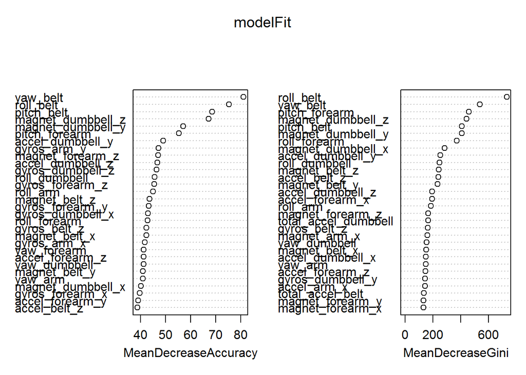

```r
varImpPlot(modelFit)
```

Plotting the variable importance plot shows “yaw_belt” and “roll_bet” to be the most significant variables/features in the model construct.

## Final Result

With such high accuracy and low error rate, the model can be applied to test dataset to predict the activity type of the 20 cases.

```r
test <- test[, c("problem_id", predictors)]

predict(modelFit, test)
```

```
##  1  2  3  4  5  6  7  8  9 10 11 12 13 14 15 16 17 18 19 20
##  B  A  B  A  A  E  D  B  A  A  B  C  B  A  E  E  A  B  B  B
## Levels: A B C D E
```